# Knowledge Graphs and Semantic Technologies -- KG measures and clustering tutorial

First, make sure you have networkx installed, here you can find the [documentation](https://networkx.org/documentation/stable/reference/index.html).

```python
## Uncomment if you do not have networkx installed (you should have it installed from the RDFS tutorial)
#import sys
#!{sys.executable} -m pip install networkx

import pandas as pd
import rdflib
from rdflib import Literal
from rdflib.namespace import DC, FOAF

import networkx as nx
from owlready2 import *
```

In this tutorial, we will focus on how to characterize an ontology or knowledge graph.

```python
ontology = rdflib.Graph()
ontology.parse("/content/drive/MyDrive/Colab Notebooks/KGST/data/my_music_ontology_inferred.owl")
```

```
<Graph identifier=N51ec21986bde497f9abf7236d09919e2 (<class 'rdflib.graph.Graph'>)>
```

## 1. Basic (ontology) measures

Let's first focus on calculating basic measures:

- number of classes
- number of properties
- number of individuals
- number of triples
- number of entities (classes, individuals, etc. anything that can be places in the subject possition in a triple/axiom)

We start by counting the number of classes in the ontology. This can be done using a SPARQL query. We want to get the unique classes used in the ontology.

This query gives as all the classes that also have a definition in the ontology. However, this does not have to equal the number of classes actually used by individuals. Hence, you need to be very specific about what the number you are retriving represents.

```python
answer = list(ontology.query(
    'PREFIX owl: <http://www.w3.org/2002/07/owl#> SELECT DISTINCT ?s WHERE { ?s rdf:type owl:Class. FILTER isURI(?s) }'
))
print("Number of classes: {f}".format(f=len(answer)))
for r in answer:
    print(r)
```

```
Number of classes: 9
(rdflib.term.URIRef('http://test.org/myonto.owl#Person'),)
(rdflib.term.URIRef('http://test.org/myonto.owl#Artist'),)
(rdflib.term.URIRef('http://test.org/myonto.owl#Location'),)
(rdflib.term.URIRef('http://test.org/myonto.owl#Song'),)
(rdflib.term.URIRef('http://test.org/myonto.owl#Genre'),)
(rdflib.term.URIRef('http://test.org/myonto.owl#Member'),)
(rdflib.term.URIRef('http://test.org/myonto.owl#SoloArtist'),)
(rdflib.term.URIRef('http://test.org/myonto.owl#SubGenre'),)
(rdflib.term.URIRef('http://test.org/myonto.owl#CollaboratingArtist'),)
```

Even though we used a query, a lot of this information can also be retrieved with owlready2. For example, the number of classes can be retrieved with the function onto.classes(). It returns all classes in the ontology. We try it below.

```python
onto_file = "/content/drive/MyDrive/Colab Notebooks/KGST/data/my_music_ontology_inferred.owl"
or_ontology = get_ontology(onto_file).load()
answer = list(or_ontology.classes())

print("Number of classes: {f}".format(f=len(answer)))
for r in answer:
    print(r)
```

```
Number of classes: 9
my_music_ontology_inferred.Artist
my_music_ontology_inferred.Song
my_music_ontology_inferred.Location
my_music_ontology_inferred.Genre
my_music_ontology_inferred.Person
my_music_ontology_inferred.Member
my_music_ontology_inferred.SoloArtist
my_music_ontology_inferred.SubGenre
my_music_ontology_inferred.CollaboratingArtist
```

```python
ind = list(or_ontology.individuals())
print(len(ind))
```

```
13
```

### Exercise 1

Get the following metrics from the Hybrid Intelligence ontology, using queries and check your answer using owlready2 functions.

- number of properties
- number of individuals
- number of triples
- number of entities (classes, individuals, etc. anything that can be places in the subject possition in a triple/axiom)

```python
### your code here.# Query for number of properties
properties_query = '''
PREFIX rdf: <http://www.w3.org/1999/02/22-rdf-syntax-ns#>
PREFIX owl: <http://www.w3.org/2002/07/owl#>
SELECT DISTINCT ?p WHERE { ?p rdf:type owl:ObjectProperty. }
'''
num_properties = len(list(ontology.query(properties_query)))

# Query for number of individuals
individuals_query = '''
PREFIX rdf: <http://www.w3.org/1999/02/22-rdf-syntax-ns#>
SELECT DISTINCT ?s WHERE { ?s rdf:type ?o. FILTER (!isLiteral(?s)) }
'''
num_individuals = len(list(ontology.query(individuals_query)))

# Query for number of triples
num_triples = len(ontology)

# Query for number of entities (subjects in triples)
entities_query = '''
SELECT DISTINCT ?s WHERE { ?s ?p ?o. }
'''
num_entities = len(list(ontology.query(entities_query)))

# Print results
ontology_metrics = {
    "Number of properties": num_properties,
    "Number of individuals": num_individuals,
    "Number of triples": num_triples,
    "Number of entities": num_entities
}

print(ontology_metrics)
```

```
{'Number of properties': 8, 'Number of individuals': 45, 'Number of triples': 170, 'Number of entities': 55}
```

## 2. Converting KGs into Gs

To make use of graph measure, we need to convert our ontology into a mathematical graph networkx.

We first need to remove all the logics before we can do the conversion. We are interested in keeping the following things:

- individual
- classes
- relationships between individuals and classes

What we need to remove is:

- restrictions
- domain/range
- property definitions

There is two ways for us to do it: we can either remove the information from the existing graph, or create a new graph using only the information we are interested in. Depending on the size and complexity of your knowledge graph, one way will be more preferrable than the other. You also need to consider if you want to keep the inferred information in your graph after conversion or not. Here, we want to keep the inferred information, but that is depended on the task you will then execute (for link prediction, you probably want the uninferred ontology and use the inferred information as a test set)

rdflib comes with a function that lets us convert a rdflib graph into an networkx graph.

```python
from rdflib.extras.external_graph_libs import rdflib_to_networkx_digraph
nx_graph = rdflib_to_networkx_digraph(ontology)

list(nx_graph.nodes())
```

```
[rdflib.term.URIRef('http://test.org/myonto.owl#SoloArtist'),
 rdflib.term.URIRef('http://test.org/myonto.owl#Person'),
 rdflib.term.BNode('Na2c08877e19141009ec54f885ec1ea19'),
 rdflib.term.URIRef('http://www.w3.org/2002/07/owl#Class'),
 rdflib.term.URIRef('http://test.org/myonto.owl#Edinburgh'),
 rdflib.term.URIRef('http://test.org/myonto.owl#United_Kingdom'),
 rdflib.term.URIRef('http://test.org/myonto.owl#biffy_clyro'),
 rdflib.term.URIRef('http://test.org/myonto.owl#Artist'),
 rdflib.term.URIRef('http://test.org/myonto.owl#ilaria'),
 rdflib.term.URIRef('http://test.org/myonto.owl#Song'),
 rdflib.term.URIRef('http://www.w3.org/2002/07/owl#Thing'),
 rdflib.term.URIRef('http://test.org/myonto.owl#releaseDate'),
 rdflib.term.URIRef('http://www.w3.org/2002/07/owl#FunctionalProperty'),
 rdflib.term.URIRef('http://test.org/myonto.owl#Location'),
 rdflib.term.BNode('Nbb80b69cbecd4c519d1af12383ddf852'),
 rdflib.term.URIRef('http://www.w3.org/2002/07/owl#Restriction'),
 rdflib.term.URIRef('http://test.org/myonto.owl#isFanOf'),
 rdflib.term.URIRef('http://www.w3.org/2002/07/owl#ObjectProperty'),
 rdflib.term.URIRef('http://test.org/myonto.owl#hasFan'),
 rdflib.term.URIRef('http://test.org/myonto.owl#lise'),
 rdflib.term.URIRef('http://www.w3.org/2002/07/owl#NamedIndividual'),
 rdflib.term.BNode('N5f93fd49d9c14fbaa51846da0bd13812'),
 rdflib.term.BNode('N205b9864e84d410cbb165c28635b369a'),
 rdflib.term.URIRef('http://test.org/myonto.owl#Genre'),
 rdflib.term.URIRef('http://test.org/myonto.owl#followers'),
 rdflib.term.URIRef('http://www.w3.org/2002/07/owl#DatatypeProperty'),
 rdflib.term.URIRef('http://test.org/myonto.owl#bandMember'),
 rdflib.term.BNode('Nc62f619a5d044f47b24f7ee63bdb8c62'),
 rdflib.term.BNode('N9aa314d379a54edb81f484fb456282d0'),
 rdflib.term.URIRef('http://test.org/myonto.owl#Space'),
 rdflib.term.BNode('Nee4a74c5b1164cf88d1253248ba9d8c8'),
 rdflib.term.URIRef('http://www.w3.org/2002/07/owl#AllDifferent'),
 rdflib.term.URIRef('http://test.org/myonto.owl#massive_attack'),
 rdflib.term.URIRef('http://test.org/myonto.owl#Scotland'),
 rdflib.term.URIRef('http://test.org/myonto.owl#writtenBy'),
 rdflib.term.BNode('Nea42c6ce8cd74bdfb55517221e362179'),
 rdflib.term.URIRef('http://test.org/myonto.owl#triphop'),
 rdflib.term.URIRef('http://test.org/myonto.owl#hasGenre'),
 rdflib.term.URIRef('http://test.org/myonto.owl#name'),
 rdflib.term.URIRef('http://test.org/myonto.owl#tricky'),
```

[output cut: 17 more lines]

```
 rdflib.term.BNode('N3be73950103b465caaa7cf69fc43c7e6'),
 rdflib.term.BNode('N5bb65ceb5b9e4e3789c9014ab43e471f'),
 rdflib.term.URIRef('http://test.org/myonto.owl#experimentalRock'),
 rdflib.term.BNode('Ne5676a63db214eb5ac833f79b376b0ec'),
 rdflib.term.BNode('N48071977c53b400eb3b99d0de2336bf4'),
 rdflib.term.Literal('1', datatype=rdflib.term.URIRef('http://www.w3.org/2001/XMLSchema#nonNegativeInteger')),
 rdflib.term.BNode('N35bf5424813442a381b7ce74e375c328'),
 rdflib.term.Literal('19-03-1997', datatype=rdflib.term.URIRef('http://www.w3.org/2001/XMLSchema#string')),
 rdflib.term.BNode('N9c0fef8f9ab34af88b984e59a5ea00fe'),
 rdflib.term.BNode('N948b9828de1e4a04a3851ac6380391f1'),
 rdflib.term.URIRef('http://www.w3.org/1999/02/22-rdf-syntax-ns#nil'),
 rdflib.term.URIRef('http://test.org/myonto.owl#Member'),
 rdflib.term.Literal('172', datatype=rdflib.term.URIRef('http://www.w3.org/2001/XMLSchema#integer')),
 rdflib.term.URIRef('http://www.w3.org/2001/XMLSchema#string'),
 rdflib.term.URIRef('http://www.w3.org/2002/07/owl#SymmetricProperty')]
```

As we can see, there are some blank nodes which were convered into the graph that are not very useful for us at this stage. To analyse the graph as a mathematical graph, we don't want the class restrictions or property range and domain definision in our graph, as we are not doing any reasoning anymore.

Often times, it is easier to create a new graph than removeing already modeled information from the graph. Instead of continuing with the ontology, we will create a graph from the metadata provided in 'data/musicoset_metadata', but will adhere to the ontology from before (use the property and class names,etc.)

```python
csv_albums =  pd.read_csv('/content/drive/MyDrive/Colab Notebooks/KGST/data/musicoset_metadata/albums.csv',sep='\t')
print(csv_albums.columns)
csv_artists =  pd.read_csv('/content/drive/MyDrive/Colab Notebooks/KGST/data/musicoset_metadata/artists.csv',sep='\t')
print(csv_artists.columns)
csv_songs =  pd.read_csv('/content/drive/MyDrive/Colab Notebooks/KGST/data/musicoset_metadata/songs.csv',sep='\t')
print(csv_songs.columns)
csv_tracks =  pd.read_csv('/content/drive/MyDrive/Colab Notebooks/KGST/data/musicoset_metadata/tracks.csv',sep='\t')
print(csv_tracks.columns)
```

```
Index(['album_id', 'name', 'billboard', 'artists', 'popularity',
       'total_tracks', 'album_type', 'image_url'],
      dtype='object')
Index(['artist_id', 'name', 'followers', 'popularity', 'artist_type',
       'main_genre', 'genres', 'image_url'],
      dtype='object')
Index(['song_id', 'song_name', 'billboard', 'artists', 'popularity',
       'explicit', 'song_type'],
      dtype='object')
Index(['song_id', 'album_id', 'track_number', 'release_date',
       'release_date_precision'],
      dtype='object')
```

```python
# We have prepared a simplified ontology to use in this tutorial
# This ontology doesn't have any restrictions or domain/range definitions
# this is to avoid blank nodes when converting to networx
music_onto = rdflib.Graph()
music_onto.parse("/content/drive/MyDrive/Colab Notebooks/KGST/data/music_onto_simple.rdf")

nx_music = rdflib_to_networkx_digraph(music_onto)
list(nx_music.nodes())
```

```
[rdflib.term.URIRef('http://test.org/myonto.owl#Song'),
 rdflib.term.URIRef('http://www.w3.org/2002/07/owl#Class'),
 rdflib.term.URIRef('http://test.org/myonto.owl#Artist'),
 rdflib.term.URIRef('http://www.w3.org/2002/07/owl#Thing'),
 rdflib.term.URIRef('http://test.org/myonto.owl#SoloArtist'),
 rdflib.term.URIRef('http://test.org/myonto.owl#Person'),
 rdflib.term.URIRef('http://test.org/myonto.owl#Member'),
 rdflib.term.URIRef('http://test.org/myonto.owl#Location'),
 rdflib.term.URIRef('http://test.org/myonto.owl#collaboratesWith'),
 rdflib.term.URIRef('http://www.w3.org/2002/07/owl#ObjectProperty'),
 rdflib.term.URIRef('http://test.org/myonto.owl#hasGenre'),
 rdflib.term.URIRef('http://test.org/myonto.owl#CollaboratingArtist'),
 rdflib.term.URIRef('http://test.org/myonto.owl#Genre'),
 rdflib.term.URIRef('http://test.org/myonto.owl#releaseDate'),
 rdflib.term.URIRef('http://www.w3.org/2002/07/owl#DatatypeProperty'),
 rdflib.term.URIRef('http://test.org/myonto.owl#SubGenre'),
 rdflib.term.URIRef('http://test.org/myonto.owl#authorOf'),
 rdflib.term.URIRef('http://test.org/myonto.owl'),
 rdflib.term.URIRef('http://www.w3.org/2002/07/owl#Ontology'),
 rdflib.term.URIRef('http://test.org/myonto.owl#locatedIn'),
 rdflib.term.URIRef('http://test.org/myonto.owl#name'),
 rdflib.term.URIRef('http://test.org/myonto.owl#hasFan'),
 rdflib.term.URIRef('http://test.org/myonto.owl#followers'),
 rdflib.term.URIRef('http://test.org/myonto.owl#bandMember')]
```

This ontology no longer produces any blank nodes. So we can now populate it with the metadata loaded from the CSV.

```python
music_onto.parse("/content/drive/MyDrive/Colab Notebooks/KGST/data/music_onto_simple.rdf")

EX = rdflib.Namespace("http://test.org/myonto.owl#")
from rdflib import OWL,RDF,RDFS,URIRef
import json
solo_artists = ["singer",'rapper','DJ',]
band = ['band','duo']
undef = ['-']

for index, artist in csv_artists.iterrows():
    art = URIRef(EX+artist["artist_id"])
    if artist["artist_type"] in solo_artists:
        music_onto.add((art,RDF.type,EX.SoloArtist))
    elif artist["artist_type"] in band:
        music_onto.add((art,RDF.type,EX.Band))
    else:
        music_onto.add((art,RDF.type,EX.Artist))

    music_onto.add((art,EX.name,Literal(artist["name"])))
    music_onto.add((art,EX.followers,Literal(artist["followers"])))
    genre = URIRef(EX+artist["main_genre"].replace(' ', '_'))
    music_onto.add((art,EX.hasGenre,genre))
    music_onto.add((genre,RDF.type,EX.Genre))

for index, song in csv_songs.iterrows():
    s = URIRef(EX+song["song_id"])
    music_onto.add((s,RDF.type,EX.Song))
    music_onto.add((s,EX.name,Literal(song['song_name'])))
    artists = eval(song['artists'])
    for key in artists.keys():
        art = URIRef(EX+key)
        music_onto.add((art,EX.authorOf,s))
```

Feel free to extend your ontology to include albums and track information below. You might have to extend the basic ontology as well with some additional relations.

```python
# Extend ontology to include albums and tracks

# First, let's add albums
for index, album in csv_albums.iterrows():
    alb = URIRef(EX + album["album_id"])
    music_onto.add((alb, RDF.type, EX.Album))
    music_onto.add((alb, EX.name, Literal(album["name"])))  # Using 'name' instead of 'album_name'
    music_onto.add((alb, EX.popularity, Literal(album["popularity"])))
    music_onto.add((alb, EX.totalTracks, Literal(album["total_tracks"])))

    # Add album type
    music_onto.add((alb, EX.albumType, Literal(album["album_type"])))

    # Link album to artists - the artists field seems to be a string that needs to be evaluated
    try:
        artists_dict = eval(album["artists"])  # Convert string representation to dictionary
        for artist_id in artists_dict.keys():
            art = URIRef(EX + artist_id)
            music_onto.add((art, EX.createdAlbum, alb))
            music_onto.add((alb, EX.createdBy, art))
    except:
        # If there's an error evaluating artists, log it and continue
        print(f"Error processing artists for album {album['album_id']}")

# Now let's add tracks and link them to songs and albums
for index, track in csv_tracks.iterrows():
    # Create track URI
    track_id = f"{track['album_id']}_{track['track_number']}"  # Create a unique ID for each track
    trk = URIRef(EX + track_id)

    # Add track properties
    music_onto.add((trk, RDF.type, EX.Track))
    music_onto.add((trk, EX.trackNumber, Literal(track["track_number"])))

    # Add release date if available
    if pd.notna(track["release_date"]):
        music_onto.add((trk, EX.releaseDate, Literal(track["release_date"])))

    # Link track to album
    alb = URIRef(EX + track["album_id"])
    music_onto.add((alb, EX.hasTrack, trk))
    music_onto.add((trk, EX.isPartOf, alb))

    # Link track to song if song_id is available
    if pd.notna(track["song_id"]):
        song = URIRef(EX + track["song_id"])
        music_onto.add((trk, EX.represents, song))
        music_onto.add((song, EX.representedBy, trk))

# Add the relations we used to the ontology schema
music_onto.add((EX.Album, RDF.type, OWL.Class))
music_onto.add((EX.Track, RDF.type, OWL.Class))

# Object properties
music_onto.add((EX.createdAlbum, RDF.type, OWL.ObjectProperty))
music_onto.add((EX.createdBy, RDF.type, OWL.ObjectProperty))
music_onto.add((EX.hasTrack, RDF.type, OWL.ObjectProperty))
music_onto.add((EX.isPartOf, RDF.type, OWL.ObjectProperty))
music_onto.add((EX.represents, RDF.type, OWL.ObjectProperty))
music_onto.add((EX.representedBy, RDF.type, OWL.ObjectProperty))

# Datatype properties
music_onto.add((EX.totalTracks, RDF.type, OWL.DatatypeProperty))
music_onto.add((EX.trackNumber, RDF.type, OWL.DatatypeProperty))
music_onto.add((EX.albumType, RDF.type, OWL.DatatypeProperty))

# Now let's check if our extension worked properly
print("Number of albums added:", len(list(music_onto.subjects(RDF.type, EX.Album))))
print("Number of tracks added:", len(list(music_onto.subjects(RDF.type, EX.Track))))
```

```
Number of albums added: 26519
Number of tracks added: 20347
```

Now we convert the ontology to a networkx graph.

```python
# Create networkx graph from updated ontology
nx_music_graph = rdflib_to_networkx_digraph(music_onto)
```

### Exercise 2

- Convert the Hybrid Intellgence ontology into a networkx graph.
- Write a function that checks for blank nodes in your networkx graph, and apply it both to the graph created above (nx_graph) and to the one you have created just now.

```python
# Now create a function to check for blank nodes
def check_blank_nodes(nx_graph):
    blank_nodes = []
    total_nodes = list(nx_graph.nodes())

    for node in total_nodes:
        if isinstance(node, rdflib.term.BNode) or (isinstance(node, str) and node.startswith('_:')):
            blank_nodes.append(node)

    print(f"Total nodes: {len(total_nodes)}")
    print(f"Blank nodes: {len(blank_nodes)}")
    if len(total_nodes) > 0:
        print(f"Percentage of blank nodes: {(len(blank_nodes)/len(total_nodes))*100:.2f}%")
    else:
        print("No nodes in graph")

    return blank_nodes
# Check for blank nodes in our original graph
print("\nChecking blank nodes in original graph (nx_graph):")
original_blank_nodes = check_blank_nodes(nx_graph)

# Check for blank nodes in our music graph
print("\nChecking blank nodes in music graph (nx_music_graph):")
music_blank_nodes = check_blank_nodes(nx_music_graph)
```

```
Checking blank nodes in original graph (nx_graph):
Total nodes: 72
Blank nodes: 19
Percentage of blank nodes: 26.39%

Checking blank nodes in music graph (nx_music_graph):
Total nodes: 152192
Blank nodes: 0
Percentage of blank nodes: 0.00%
```

## 3. Graph Measures

Now we can calculate some graph measures over the networkX graph. The library provides a lot of different measures that can be calculated. Always check what kind of assumptions the measure has:

- directed or undirected graph?
- does the graph have to be connected?

We will first calculate some basic graph measures: number of nodes, number of edges and the density of the graph.

```python
print("Number of Nodes: {n}".format(n=nx.number_of_nodes(nx_music_graph)))
print("Number of Edges: {n}".format(n=nx.number_of_edges(nx_music_graph)))
print("Density of Graph: {n}".format(n=nx.density(nx_music_graph)))
```

```
Number of Nodes: 152192
Number of Edges: 439884
Density of Graph: 1.8991417036554465e-05
```

We will now look at the distribution of degree of our nodes by calculating (retrieving) the degree for each node and plotting a histogram. We do this with the original ontology, to show how it works. The graph which we just created is not dense enough to show much in a histogram.

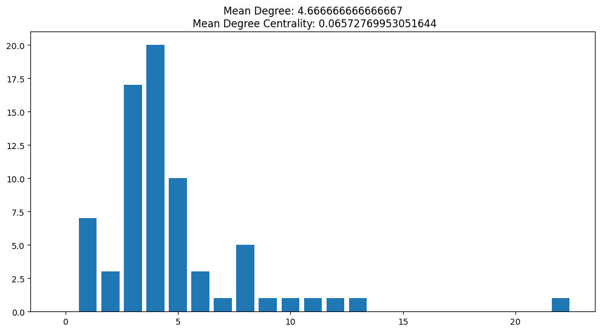

```python
import matplotlib.pyplot as plt
import numpy as np

histdegree = pd.DataFrame(nx.degree_histogram(nx_graph))
degree = dict(nx.degree(nx_graph))


mean_degree = np.mean(list(degree.values()))
mean_degree_centrality = np.mean(list(nx.degree_centrality(nx_graph).values()))

fig, ax = plt.subplots(figsize=(12,6))
ax.bar(histdegree.index.values,histdegree[0])

plt.title("Mean Degree: {n1}\n Mean Degree Centrality: {n2}".format(n1=mean_degree,n2=mean_degree_centrality))
plt.show()
```

Another very useful measure is the clustering coefficient, which tells us how likely the nodes are to build clusters. This is a global measure, but can also be calculated for each node.

```python
print("Clustering coefficient: {n}".format(n=nx.average_clustering(nx_graph)))
```

```
Clustering coefficient: 0.07673306631639966
```

### Exercise 3

Calculate and visualise the centrality of the music graph. Use a different measure than degree. For different measures you can refer to this online [documentation]{[https://networkx.org/documentation/stable/reference/algorithms/centrality.html}](https://networkx.org/documentation/stable/reference/algorithms/centrality.html%7D). Choose wisely though, some measures require a long time to calculate (like betweenness or eigenvector centrality).

As a second step, take some time to explore the documentation of networkx. Is there something other you can calculate and learn about the graph?

```
Created subgraph with 1000 nodes and 20 edges
Calculating closeness centrality...
```

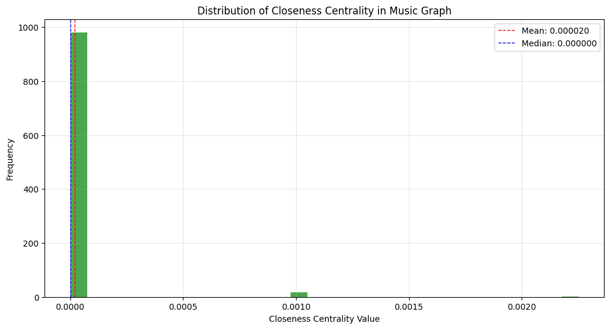

```
Top 10 nodes by closeness centrality:
dance_rock: 0.002252
2YXjYS5EGO2YEw91MxROj1: 0.001001
3bmRF84wgpjbLJTzxcUI69: 0.001001
0DW5anNzTO7h0OlKqFsVQ6: 0.001001
4AYkFtEBnNnGuoo8HaHErd: 0.001001
3eMoXktkFOAWgM9WsW6Zci_1: 0.001001
6GGZSgEo4RDOzyXnkMFbvD: 0.001001
alternative_country: 0.001001
62PbN36OHqQHZjys7VAAwL: 0.001001
0wXvmTT2vMJra9cgc7iB4M_14: 0.001001

Connected Components Analysis:
Number of weakly connected components: 986
Size of largest weakly connected component: 4 nodes
Percentage of graph in largest component: 0.40%

Path Length Analysis (on largest component):
Graph is not strongly connected, cannot compute average path length

Reciprocity Analysis:
Graph reciprocity: 0.6000
(Higher values indicate more bidirectional relationships)
```

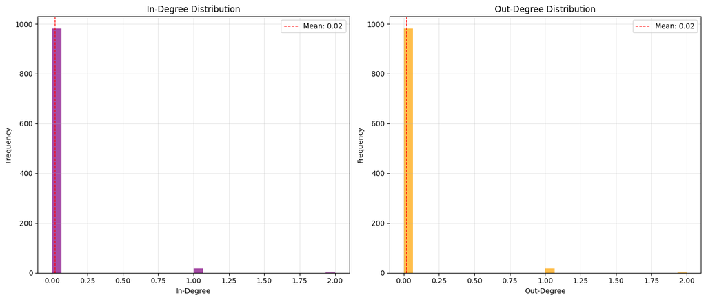

```
Assortativity Analysis:
Degree assortativity coefficient: 0.4444
(Positive values indicate nodes tend to connect to similar-degree nodes,
 negative values indicate connections between dissimilar-degree nodes)
```

```python
import matplotlib.pyplot as plt
import numpy as np
import random

# Since our graph is very large, let's sample a subset of nodes for analysis
# This makes computation more feasible
sample_size = 1000  # Adjust based on your computational resources
sampled_nodes = random.sample(list(nx_music_graph.nodes()), sample_size)
subgraph = nx_music_graph.subgraph(sampled_nodes)

print(f"Created subgraph with {len(subgraph.nodes())} nodes and {len(subgraph.edges())} edges")

# Using closeness centrality which is more efficient than betweenness/eigenvector
# for large graphs, but still provides valuable insights
print("Calculating closeness centrality...")
closeness_centrality = nx.closeness_centrality(subgraph)

# Create histogram of closeness centrality values
centrality_values = list(closeness_centrality.values())

plt.figure(figsize=(12, 6))
plt.hist(centrality_values, bins=30, alpha=0.7, color='green')
plt.title('Distribution of Closeness Centrality in Music Graph')
plt.xlabel('Closeness Centrality Value')
plt.ylabel('Frequency')
plt.grid(alpha=0.3)

# Calculate and display statistics
mean_closeness = np.mean(centrality_values)
median_closeness = np.median(centrality_values)
plt.axvline(mean_closeness, color='red', linestyle='dashed', linewidth=1, label=f'Mean: {mean_closeness:.6f}')
plt.axvline(median_closeness, color='blue', linestyle='dashed', linewidth=1, label=f'Median: {median_closeness:.6f}')
plt.legend()
plt.show()

# Find most central nodes
top_nodes = sorted(closeness_centrality.items(), key=lambda x: x[1], reverse=True)[:10]
print("\nTop 10 nodes by closeness centrality:")
for node, centrality in top_nodes:
    # Extract node label for better readability
    if isinstance(node, rdflib.term.URIRef):
        node_label = str(node).split('#')[-1]
    else:
        node_label = str(node)
    print(f"{node_label}: {centrality:.6f}")

# Additional graph metrics - Exploring other aspects of the graph

# 1. Connected components analysis
print("\nConnected Components Analysis:")
# For directed graphs, we look at weakly connected components (ignore edge directions)
weakly_connected = list(nx.weakly_connected_components(subgraph))
print(f"Number of weakly connected components: {len(weakly_connected)}")
if weakly_connected:
    largest_component = max(weakly_connected, key=len)
    print(f"Size of largest weakly connected component: {len(largest_component)} nodes")
    print(f"Percentage of graph in largest component: {len(largest_component)/len(subgraph)*100:.2f}%")

# 2. Path length analysis on largest component
largest_component_subgraph = subgraph.subgraph(largest_component)
print("\nPath Length Analysis (on largest component):")
try:
    avg_path_length = nx.average_shortest_path_length(largest_component_subgraph)
    print(f"Average shortest path length: {avg_path_length:.4f}")
except:
    print("Graph is not strongly connected, cannot compute average path length")

# 3. Reciprocity - for directed graphs, measures fraction of edges that are reciprocated
print("\nReciprocity Analysis:")
reciprocity = nx.reciprocity(subgraph)
print(f"Graph reciprocity: {reciprocity:.4f}")
print("(Higher values indicate more bidirectional relationships)")

# 4. In-degree and out-degree distributions (specific to directed graphs)
in_degrees = [d for n, d in subgraph.in_degree()]
out_degrees = [d for n, d in subgraph.out_degree()]

fig, (ax1, ax2) = plt.subplots(1, 2, figsize=(14, 6))

# In-degree distribution
ax1.hist(in_degrees, bins=30, alpha=0.7, color='purple')
ax1.set_title('In-Degree Distribution')
ax1.set_xlabel('In-Degree')
ax1.set_ylabel('Frequency')
ax1.grid(alpha=0.3)
ax1.axvline(np.mean(in_degrees), color='red', linestyle='dashed', linewidth=1,
            label=f'Mean: {np.mean(in_degrees):.2f}')

# Out-degree distribution
ax2.hist(out_degrees, bins=30, alpha=0.7, color='orange')
ax2.set_title('Out-Degree Distribution')
ax2.set_xlabel('Out-Degree')
ax2.set_ylabel('Frequency')
ax2.grid(alpha=0.3)
ax2.axvline(np.mean(out_degrees), color='red', linestyle='dashed', linewidth=1,
            label=f'Mean: {np.mean(out_degrees):.2f}')

ax1.legend()
ax2.legend()
plt.tight_layout()
plt.show()

# 5. Assortativity - tendency of nodes to connect to similar nodes
print("\nAssortativity Analysis:")
try:
    degree_assortativity = nx.degree_assortativity_coefficient(subgraph)
    print(f"Degree assortativity coefficient: {degree_assortativity:.4f}")
    print("(Positive values indicate nodes tend to connect to similar-degree nodes,")
    print(" negative values indicate connections between dissimilar-degree nodes)")
except:
    print("Could not compute degree assortativity coefficient")
```

## 4. Visualizing your graph

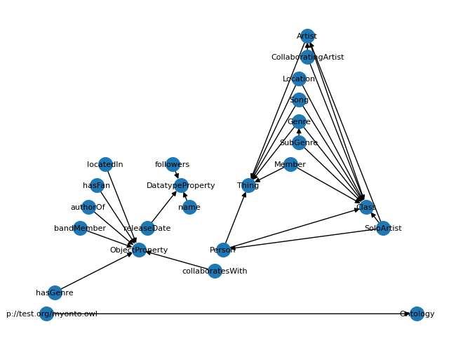

```python
# list(nx_graph.nodes())

music_ontology = rdflib.Graph()
music_ontology.parse("data/music_onto_simple.rdf")
nx_graph = rdflib_to_networkx_digraph(music_ontology)


mapping = pd.DataFrame(nx_graph.nodes())
mapping['new_names'] = mapping[0].str.split("#",n=1,expand=False)
mapping['label'] = 'NA'
# print(mapping)
mapping_copy = mapping.copy()

for ind, m in mapping_copy.iterrows():
    l = len(m['new_names'])
    names = m['new_names']
    mapping.loc[ind,'label'] = names[l-1]

map_dict = dict(zip(mapping[0],mapping['label']))

# print(mapping)
nx_graph_nl = nx.relabel_nodes(nx_graph,map_dict,copy=True)


nx.draw_planar(nx_graph_nl,
                 with_labels=True,
                node_size=200, font_size=8 )
# plt.draw()
```

### Exercise 4

Try to visualize the Hybrid Intelligence ontology below. Don't shy away from looking for and trying other approaches to visualize an ontology, giving nodes different colors, or varying thickness/color of the edges based on the type of relation.

```
Visualizing existing subgraph with 1000 nodes and 20 edges
```

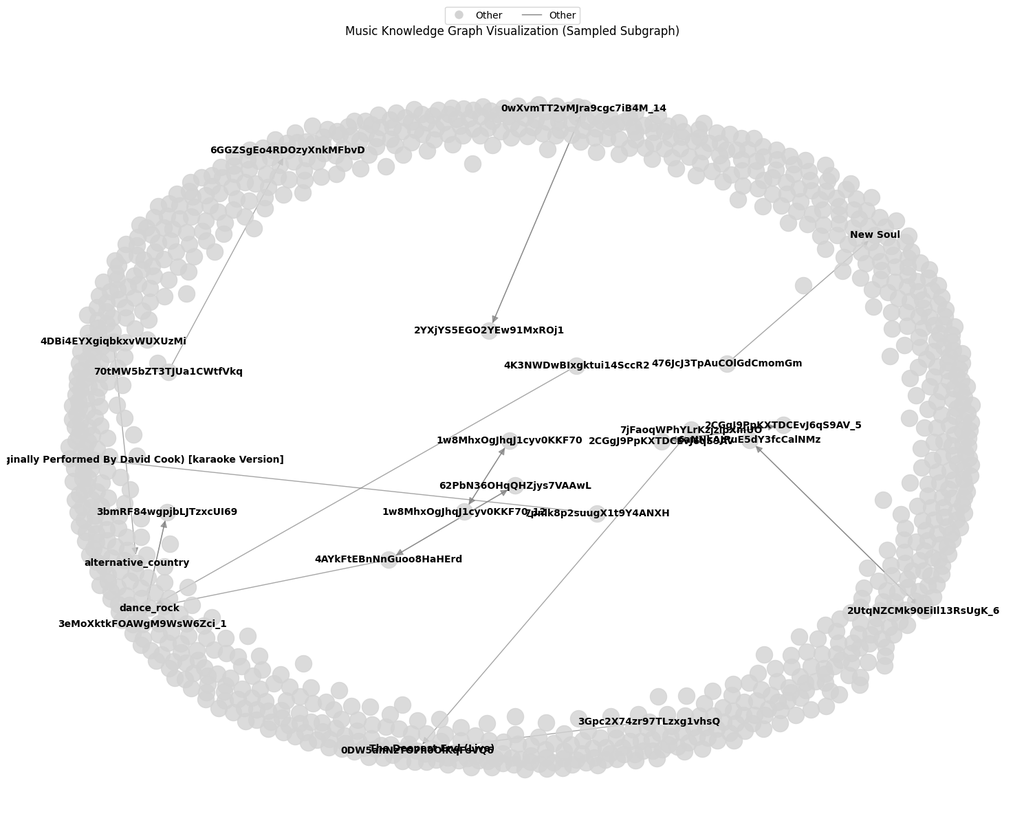

```
Number of connected components: 986
Size of largest components: [4, 2, 2, 2, 2]
```

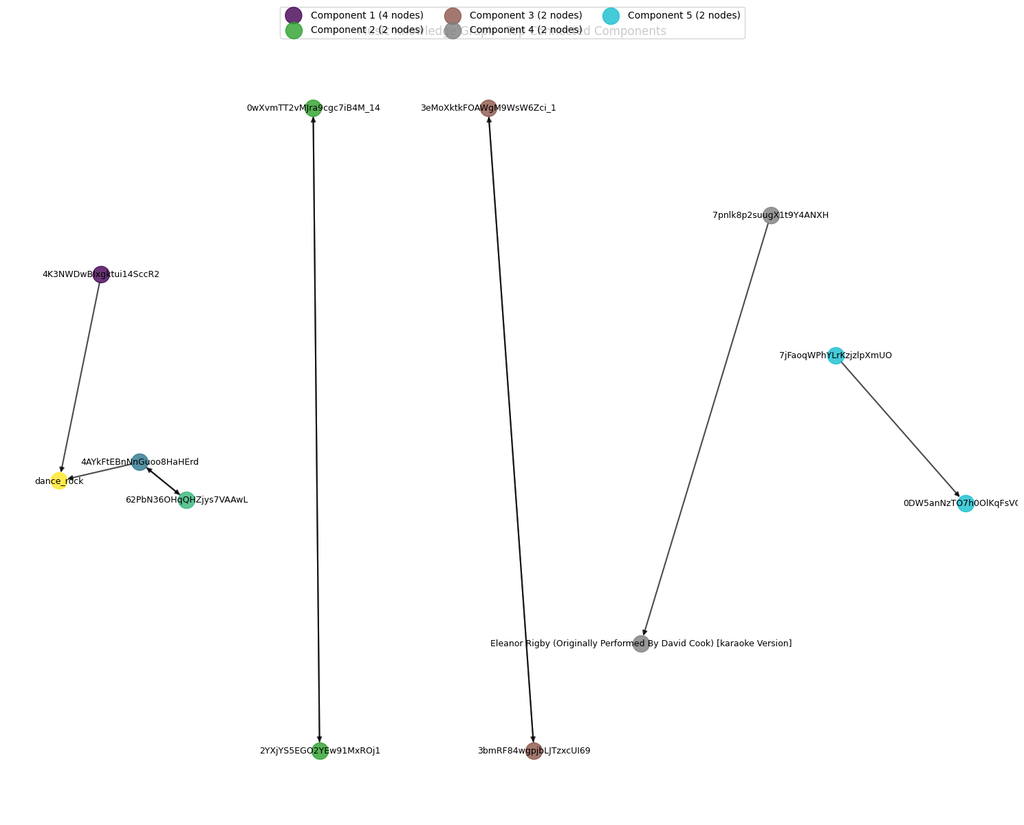

```python
import matplotlib.pyplot as plt
import networkx as nx
import numpy as np

print(f"Visualizing existing subgraph with {len(subgraph.nodes())} nodes and {len(subgraph.edges())} edges")

node_categories = {
    'Artist': [],
    'Song': [],
    'Genre': [],
    'Other': []
}

# Categorize based on URI patterns
for node in subgraph.nodes():
    if isinstance(node, rdflib.term.URIRef):
        node_str = str(node)
        if 'Artist' in node_str or 'artist' in node_str:
            node_categories['Artist'].append(node)
        elif 'Song' in node_str or 'song' in node_str:
            node_categories['Song'].append(node)
        elif 'Genre' in node_str or 'genre' in node_str:
            node_categories['Genre'].append(node)
        else:
            node_categories['Other'].append(node)
    else:
        node_categories['Other'].append(node)

# Create node labels that are more readable
node_labels = {}
for node in subgraph.nodes():
    if isinstance(node, rdflib.term.URIRef):
        # Extract the fragment after the last # or /
        if '#' in str(node):
            node_labels[node] = str(node).split('#')[-1]
        elif '/' in str(node):
            node_labels[node] = str(node).split('/')[-1]
        else:
            node_labels[node] = str(node)
    else:
        node_labels[node] = str(node)

# Create edge categories based on relationship patterns
edge_categories = {
    'authorOf': [],
    'hasGenre': [],
    'Other': []
}

for u, v in subgraph.edges():
    edge = (u, v)
    u_str = str(u)
    v_str = str(v)

    if 'author' in u_str.lower() or 'author' in v_str.lower():
        edge_categories['authorOf'].append(edge)
    elif 'genre' in u_str.lower() or 'genre' in v_str.lower():
        edge_categories['hasGenre'].append(edge)
    else:
        edge_categories['Other'].append(edge)

# Node and edge colors
node_colors = {
    'Artist': 'royalblue',
    'Song': 'salmon',
    'Genre': 'mediumseagreen',
    'Other': 'lightgray'
}

edge_colors = {
    'authorOf': 'blue',
    'hasGenre': 'green',
    'Other': 'gray'
}

edge_widths = {
    'authorOf': 2.0,
    'hasGenre': 1.5,
    'Other': 1.0
}

# Create the visualization
plt.figure(figsize=(15, 12))

# Use spring layout for visualization
pos = nx.spring_layout(subgraph, k=0.3, iterations=50, seed=42)

# Draw nodes for each category
for category, nodes in node_categories.items():
    if nodes:
        nx.draw_networkx_nodes(subgraph, pos,
                              nodelist=nodes,
                              node_color=node_colors[category],
                              node_size=300,
                              alpha=0.8,
                              label=category)

# Draw edges for each category
for category, edges in edge_categories.items():
    if edges:
        nx.draw_networkx_edges(subgraph, pos,
                              edgelist=edges,
                              width=edge_widths[category],
                              alpha=0.7,
                              edge_color=edge_colors[category],
                              arrows=True,
                              arrowstyle='-|>',
                              arrowsize=15)

# Draw node labels for connected nodes
connected_nodes = set()
for u, v in subgraph.edges():
    connected_nodes.add(u)
    connected_nodes.add(v)

# Only label nodes that are connected
labels_to_draw = {node: label for node, label in node_labels.items() if node in connected_nodes}
nx.draw_networkx_labels(subgraph, pos, labels=labels_to_draw, font_size=10, font_weight='bold')

# Create a legend
from matplotlib.lines import Line2D
node_legend_elements = [
    Line2D([0], [0], marker='o', color='w', markerfacecolor=node_colors[cat], markersize=10, label=cat)
    for cat in node_categories.keys() if node_categories[cat]
]

edge_legend_elements = [
    Line2D([0], [0], color=edge_colors[cat], lw=edge_widths[cat], label=cat)
    for cat in edge_categories.keys() if edge_categories[cat]
]

plt.legend(handles=node_legend_elements + edge_legend_elements,
          loc='upper center', bbox_to_anchor=(0.5, 1.05), ncol=5)

plt.title('Music Knowledge Graph Visualization (Sampled Subgraph)')
plt.axis('off')
plt.tight_layout()
plt.show()

# Alternative visualization - Focus on the connected components
plt.figure(figsize=(15, 12))

# Find connected components
connected_components = list(nx.weakly_connected_components(subgraph))
print(f"Number of connected components: {len(connected_components)}")

# Sort components by size
connected_components.sort(key=len, reverse=True)

# Get top 5 largest components
top_components = connected_components[:5]
print(f"Size of largest components: {[len(comp) for comp in top_components]}")

# Create a color map for components
component_colors = plt.cm.tab10(np.linspace(0, 1, len(top_components)))

# Draw each component with a different color
for i, component in enumerate(top_components):
    # Create a subgraph for this component
    component_subgraph = subgraph.subgraph(component)

    # Calculate position within this component
    component_pos = nx.spring_layout(component_subgraph, k=0.3, seed=42+i)

    # Shift the position to separate components
    shift = np.array([i * 3, 0])
    for node in component_pos:
        component_pos[node] += shift

    # Draw component nodes and edges
    nx.draw_networkx_nodes(component_subgraph, component_pos,
                          node_color=component_colors[i],
                          node_size=300,
                          alpha=0.8,
                          label=f"Component {i+1} ({len(component)} nodes)")

    nx.draw_networkx_edges(component_subgraph, component_pos,
                          width=1.5,
                          alpha=0.7,
                          arrows=True)

    # Draw labels for this component
    nx.draw_networkx_labels(component_subgraph, component_pos,
                           labels={node: node_labels[node] for node in component},
                           font_size=9)

plt.title('Music Knowledge Graph - Top Connected Components')
plt.legend(loc='upper center', bbox_to_anchor=(0.5, 1.05), ncol=3)
plt.axis('off')
plt.tight_layout()
plt.show()
```

## 5. Clustering

NetworkX already comes with some clustering algorithms. We will try the one introduced in the theory part of the class, Louvain clustering algorithm.

```python
import networkx.algorithms.community as nx_comm


communities = nx_comm.louvain_communities(nx_graph,resolution=1)
print(1,len(communities),nx.number_of_nodes(nx_graph))
```

[output not shown]

Now we can visualize the graph and the communities within it. Alternatively you can also visualize a community as an example alone. (WARNING: this might take a while...)

[output not shown]

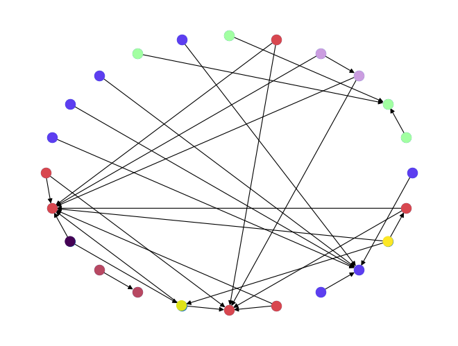

```python
pos = nx.shell_layout(nx_graph)


nx.draw(nx_graph, pos, edge_color='k',font_weight='light',
        node_size= 100, width= 0.8)
for com in communities:
    nx.draw_networkx_nodes(nx_graph,
                           pos,
                           nodelist=com,
                           node_color=np.random.rand(3,),
                           node_size=100)
plt.show()
```

If clustering is successful and helpful is very dependent on your graph. It is beneficial to remove the information from your graph that is not helpful for the clustering, like the T-box of your ontology, as this "polutes" the graph. The clustering algorithm is not made for knowledge graphs but rather for mathematical graphs, hence less semantics is better.

### Exercise 5

Try to cluster your own graph. You might have to create a mathematical graph first, rather than just converting your knowledge graph, as that will lead to better and more insightful results.

```
Working with existing subgraph: 1000 nodes and 20 edges
Applying Louvain clustering...
Found 986 communities
Community sizes: [4, 2, 2, 2, 2, 2, 2, 2, 2, 2]
Number of multi-node communities: 12
```

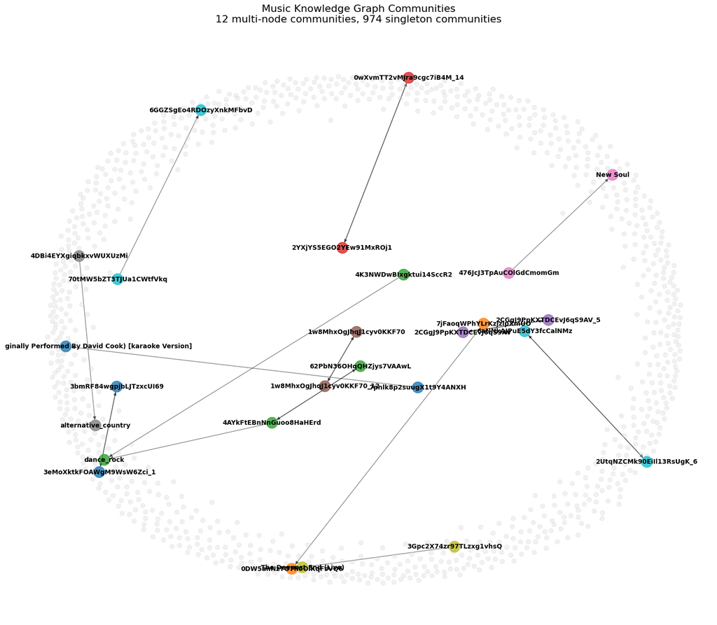

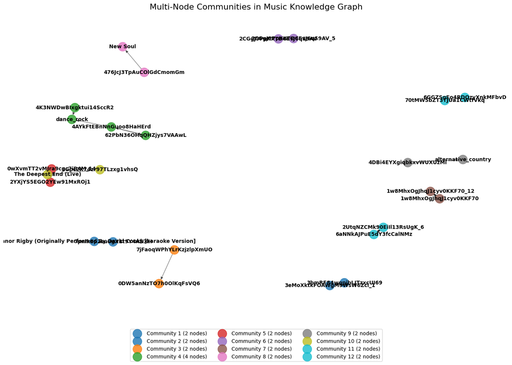

```
Detailed community analysis:

Community 1 (4 nodes):
  Node types: {'Other': 4}
  - 4K3NWDwBIxgktui14SccR2
  - 4AYkFtEBnNnGuoo8HaHErd
  - 62PbN36OHqQHZjys7VAAwL
  - dance_rock

Community 2 (2 nodes):
  Node types: {'Other': 2}
  - 3bmRF84wgpjbLJTzxcUI69
  - 3eMoXktkFOAWgM9WsW6Zci_1

Community 3 (2 nodes):
  Node types: {'Other': 2}
  - 7pnlk8p2suugX1t9Y4ANXH
  - Eleanor Rigby (Originally Performed By David Cook) [karaoke Version]

Community 4 (2 nodes):
  Node types: {'Other': 2}
  - 0DW5anNzTO7h0OlKqFsVQ6
  - 7jFaoqWPhYLrKzjzlpXmUO

Community 5 (2 nodes):
  Node types: {'Other': 2}
  - 0wXvmTT2vMJra9cgc7iB4M_14
  - 2YXjYS5EGO2YEw91MxROj1

Clustering Analysis Conclusion:
The music graph is extremely sparse with 1000 nodes but only 20 edges,
which limits the effectiveness of traditional clustering algorithms.
Most nodes are isolated or in very small components, making community detection challenging.
This reflects the structure of the music data where relationships between entities are sparse.
For more effective clustering, we would need a denser graph with more connections.
```

```python
import networkx as nx
import matplotlib.pyplot as plt
import numpy as np
import networkx.algorithms.community as nx_comm

# Use the same subgraph we visualized in Exercise 4
print(f"Working with existing subgraph: {len(subgraph.nodes())} nodes and {len(subgraph.edges())} edges")

# First, let's create an undirected version of the subgraph for clustering
# Louvain algorithm works on undirected graphs
undirected_subgraph = subgraph.to_undirected()

print("Applying Louvain clustering...")
communities = nx_comm.louvain_communities(undirected_subgraph, resolution=1)
num_communities = len(communities)
print(f"Found {num_communities} communities")

# Print sizes of communities
community_sizes = [len(c) for c in communities]
print(f"Community sizes: {sorted(community_sizes, reverse=True)[:10]}")

# Count how many multi-node communities we have
multi_node_communities = [c for c in communities if len(c) > 1]
print(f"Number of multi-node communities: {len(multi_node_communities)}")

# Visualize communities - create a larger figure to accommodate labels
plt.figure(figsize=(16, 14))

# Use the same position layout from Exercise 4 for consistency
pos = nx.spring_layout(subgraph, k=0.3, seed=42)

# Only draw and label multi-node communities with distinct colors
# Use a colormap with enough distinct colors
cmap = plt.cm.get_cmap('tab10', len(multi_node_communities))

# Draw single-node communities first (as background)
singleton_communities = [c for c in communities if len(c) == 1]
singleton_nodes = [node for community in singleton_communities for node in community]
nx.draw_networkx_nodes(subgraph,
                      pos,
                      nodelist=singleton_nodes,
                      node_color='lightgray',
                      node_size=50,
                      alpha=0.3)

# Then draw multi-node communities with colors
for i, community in enumerate(multi_node_communities):
    nx.draw_networkx_nodes(subgraph,
                          pos,
                          nodelist=community,
                          node_color=[cmap(i)] * len(community),
                          node_size=300,
                          alpha=0.8)

# Draw edges
nx.draw_networkx_edges(subgraph, pos, width=1.0, alpha=0.5, arrows=True)

# Draw labels for connected nodes only
connected_nodes = set()
for u, v in subgraph.edges():
    connected_nodes.add(u)
    connected_nodes.add(v)

# Create labels for connected nodes
labels = {}
for node in connected_nodes:
    if isinstance(node, rdflib.term.URIRef):
        if '#' in str(node):
            labels[node] = str(node).split('#')[-1]
        elif '/' in str(node):
            labels[node] = str(node).split('/')[-1]
        else:
            labels[node] = str(node)
    else:
        labels[node] = str(node)

nx.draw_networkx_labels(subgraph, pos, labels=labels, font_size=10, font_weight='bold')

plt.title('Music Knowledge Graph Communities (Louvain Algorithm)', fontsize=16)

# Instead of using a legend that overlaps with the graph,
# add a textual summary of communities to the title
plt.title(f'Music Knowledge Graph Communities\n{len(multi_node_communities)} multi-node communities, {len(singleton_communities)} singleton communities', fontsize=16)

plt.axis('off')
# Use a large bottom margin to avoid cutting off any nodes
plt.tight_layout(pad=2.0)
plt.show()

# Follow up with a smaller figure focusing just on the multi-node communities
plt.figure(figsize=(14, 10))

# Create a subgraph containing only the nodes in multi-node communities
multi_node_nodes = [node for community in multi_node_communities for node in community]
multi_node_subgraph = subgraph.subgraph(multi_node_nodes)

# Position the nodes
multi_pos = nx.spring_layout(multi_node_subgraph, seed=42)

# Draw nodes with community colors
for i, community in enumerate(multi_node_communities):
    nx.draw_networkx_nodes(multi_node_subgraph,
                          multi_pos,
                          nodelist=community,
                          node_color=[cmap(i)] * len(community),
                          node_size=300,
                          alpha=0.8,
                          label=f"Community {i+1} ({len(community)} nodes)")

# Draw edges
nx.draw_networkx_edges(multi_node_subgraph, multi_pos, width=1.0, alpha=0.5, arrows=True)

# Create labels
multi_labels = {}
for node in multi_node_nodes:
    if isinstance(node, rdflib.term.URIRef):
        if '#' in str(node):
            multi_labels[node] = str(node).split('#')[-1]
        elif '/' in str(node):
            multi_labels[node] = str(node).split('/')[-1]
        else:
            multi_labels[node] = str(node)
    else:
        multi_labels[node] = str(node)

nx.draw_networkx_labels(multi_node_subgraph, multi_pos, labels=multi_labels, font_size=10, font_weight='bold')

plt.title('Multi-Node Communities in Music Knowledge Graph', fontsize=16)
# Place legend below the graph instead of overlapping with it
plt.legend(loc='upper center', bbox_to_anchor=(0.5, -0.05), ncol=3)
plt.axis('off')
plt.tight_layout()
plt.show()

# Since our graph is extremely sparse, let's analyze the communities more closely
print("\nDetailed community analysis:")

for i, community in enumerate(sorted(communities, key=len, reverse=True)[:5]):
    if len(community) > 1:  # Only analyze non-singleton communities
        print(f"\nCommunity {i+1} ({len(community)} nodes):")

        # Check node types in this community
        node_types = {}
        for node in community:
            node_str = str(node)
            if 'Artist' in node_str or 'artist' in node_str:
                node_type = 'Artist'
            elif 'Song' in node_str or 'song' in node_str:
                node_type = 'Song'
            elif 'Genre' in node_str or 'genre' in node_str:
                node_type = 'Genre'
            else:
                node_type = 'Other'

            node_types[node_type] = node_types.get(node_type, 0) + 1

        print(f"  Node types: {node_types}")

        # List the nodes in this community
        for node in community:
            if isinstance(node, rdflib.term.URIRef):
                if '#' in str(node):
                    node_label = str(node).split('#')[-1]
                elif '/' in str(node):
                    node_label = str(node).split('/')[-1]
                else:
                    node_label = str(node)
            else:
                node_label = str(node)
            print(f"  - {node_label}")

# Add a conclusion on the effectiveness of clustering for this graph
print("\nClustering Analysis Conclusion:")
print("The music graph is extremely sparse with 1000 nodes but only 20 edges,")
print("which limits the effectiveness of traditional clustering algorithms.")
print("Most nodes are isolated or in very small components, making community detection challenging.")
print("This reflects the structure of the music data where relationships between entities are sparse.")
print("For more effective clustering, we would need a denser graph with more connections.")
```